# ERF Paper

Tegveer Ghura

2023-02-10

```r
# df import and subset
df <- read_csv('Data/REKT_Database_Clean_Python.csv')
df <- subset(df, select = -c(...1, token_name, description, name_categories))
#df <- df %>% filter(funds_lost!=0)
```

```r
# Removing dictionary values from the scam_type column
df$scam_type <- gsub("[^:]*,[^:]*", "",df$scam_type)
df$scam_type <- gsub("'id'::", "",df$scam_type)
df$scam_type <- gsub("\\{|\\}", "",df$scam_type)
df$scam_type <- gsub("'", "",df$scam_type)
df$scam_type <- gsub("type: ", "",df$scam_type)
df$scam_type <- gsub(" ", "",df$scam_type)

# Removing list brackets from the scamNetworks column
df$scamNetworks <- gsub("\\[|\\]", "", df$scamNetworks)
df$scamNetworks <- gsub("'", '', df$scamNetworks)
df$scamNetworks <- gsub(", +", ",", df$scamNetworks) # remove whitespace after comma for grouping later
```

```r
# pooling together scam types into respective types
df <- df %>%
  mutate(scam_type_grouped = if_else(scam_type=="Honeypot" | scam_type=="Rugpull" | scam_type=="Abandoned" | project_name=="Kronos Dao" | project_name=="Genesis" | project_name=="Celsius Network" | project_name=="Voyager" | project_name=="BlockFi" | project_name=="FTX Group" | project_name=="Bitcoin Sheikh" | project_name=="Trade Coin Club" | project_name=="EmpiresX" | project_name=="Vauld", "Exit Scam", "Exploit"))
df <- subset(df, select = -c(scam_type, day_of_week_of_attack, day_of_year_of_attack, date, project_name))
table(df$scam_type_grouped)
```

```
##
## Exit Scam   Exploit
##      2677       486
```

```r
#only month_of_attack has NA's (1873 of them), we can impute "unknown" for them or get rid of the column. Let's first see the performance from imputation
df$month_of_attack=month.name[df$month_of_attack]
df$month_of_attack[is.na(df$month_of_attack)] <- "Unknown"
#df <- na.omit(df)
```

```r
# pooling scamNetworks into 5 levels (Eth, binance, polygon, other centralized, other decentralized)
df <- separate_rows(df,scamNetworks,sep = ",")
df <- df %>%
  mutate(scam_networks_grouped = if_else(scamNetworks == "Avax" | scamNetworks == "Algorand" | scamNetworks == "Arbitrum" | scamNetworks == "Cosmos" | scamNetworks == "Cronos" | scamNetworks == "Elastos" | scamNetworks == "Elrond" | scamNetworks == "EOS" | scamNetworks == "Fantom" | scamNetworks == "Fuse" | scamNetworks == "Gnosis" | scamNetworks == "Harmony" | scamNetworks == "Heco" | scamNetworks == "Klaytn" | scamNetworks == "KuCoin" | scamNetworks == "Moonriver" | scamNetworks == "Near" | scamNetworks == "OKExChain" | scamNetworks == "Optimism" | scamNetworks == "Ronin" | scamNetworks == "RSK" | scamNetworks == "Solana" | scamNetworks == "TRON" | scamNetworks == "Polkadot" | scamNetworks == "Other" | scamNetworks == "Terra Classic", "Other Decentralized", scamNetworks))
df <- df %>% filter(scam_networks_grouped != "") # remove empty string level
df <- subset(df, select = -c(scamNetworks))
```

```r
# specify dtypes before train test split

df$scam_networks_grouped <- as.factor(df$scam_networks_grouped)
df$scam_type_grouped <-as.factor(df$scam_type_grouped)
df$month_of_attack <-as.factor(df$month_of_attack)

# add +1 because we have zeros in funds_returned and helps avoid negative inf values

df$log_funds_lost <- log(df$funds_lost + 1)
df$log_funds_returned <- log(df$funds_returned + 1)
df <- subset(df, select = -c(funds_lost, funds_returned))
```

```r
library(caret)

set.seed(3738)

df <- df[sample(1:nrow(df)), ] # shuffle rows

train.index <- createDataPartition(df$scam_networks_grouped,
                                   p = .8, list = FALSE)
train <- df[ train.index,]
test  <- df[-train.index,]

x_train <- train %>% select(log_funds_lost, log_funds_returned,
                            scam_networks_grouped)
y_train <- train$scam_type_grouped

x_test <- test %>% select(log_funds_lost, log_funds_returned,
                          scam_networks_grouped)
y_test <- test$scam_type_grouped

classifier_RF <- randomForest(x = x_train,
                             y = y_train,
                             ntree = 500)

classifier_RF
```

```
##
## Call:
##  randomForest(x = x_train, y = y_train, ntree = 500)
##                Type of random forest: classification
##                      Number of trees: 500
## No. of variables tried at each split: 1
##
##         OOB estimate of  error rate: 7.53%
## Confusion matrix:
##           Exit Scam Exploit class.error
## Exit Scam      2052      98   0.0455814
## Exploit          95     318   0.2300242
```

```r
# Predicting the Test set results
y_pred = predict(classifier_RF, newdata = x_test)

# Confusion Matrix
confusion_mtx = table(y_test, y_pred)
confusion_mtx
```

```
##            y_pred
## y_test      Exit Scam Exploit
##   Exit Scam       504      23
##   Exploit          37      73
```

```r
#Evaluate variable importance

jpeg("VarImpRF.jpg", width = 700, height = 350)
importance(classifier_RF)
```

```
##                       MeanDecreaseGini
## log_funds_lost               240.56063
## log_funds_returned            39.59532
## scam_networks_grouped         71.51662
```

```r
varImpPlot(classifier_RF, main="Variable Importance: Random Forest")
# Close the jpeg file
dev.off()
```

```r
rf_train <- predict(classifier_RF, x_train, type = 'prob')
rf_test <- predict(classifier_RF, x_test, type = 'prob')

train.rf <- prediction(rf_train[,2], y_train)
test.rf <- prediction(rf_test[,2], y_test)

rf_perf_train <- performance(train.rf, "tpr", "fpr")
rf_perf_test <- performance(test.rf, "tpr", "fpr")
```

```r
library(caret)
set.seed(2377)
train.index <- createDataPartition(df$scam_networks_grouped,
                                   p = .8, list = FALSE)
train <- df[ train.index,]
test  <- df[-train.index,]

train$scam_type_grouped = ifelse(train$scam_type_grouped  == "Exploit", 1, 0)
test$scam_type_grouped = ifelse(test$scam_type_grouped  == "Exploit", 1, 0)
logistic_model <- glm(scam_type_grouped ~ ., data = train, family = binomial(link = "logit"))
```

```r
# logistic_model_summary <- summary(logistic_model)
# logistic_model_summary
stargazer::stargazer(logistic_model,type='text',report = "vc*stp",
    ci = TRUE)
```

==================================================================== Dependent variable:  
————————— scam_type_grouped  
——————————————————————– month_of_attackAugust -1.153**  
(-2.240, -0.066)  
t = -2.078  
p = 0.038

month_of_attackDecember -1.396**  
(-2.466, -0.326)  
t = -2.557  
p = 0.011

month_of_attackFebruary -0.707  
(-1.839, 0.424)  
t = -1.225  
p = 0.221

month_of_attackJanuary -2.012***  
(-3.149, -0.875)  
t = -3.468  
p = 0.001

month_of_attackJuly -0.318  
(-1.414, 0.777)  
t = -0.569  
p = 0.570

month_of_attackJune -0.479  
(-1.581, 0.624)  
t = -0.851  
p = 0.395

month_of_attackMarch -0.800  
(-1.907, 0.307)  
t = -1.416  
p = 0.157

month_of_attackMay -0.554  
(-1.666, 0.558)  
t = -0.976  
p = 0.330

month_of_attackNovember -1.260**  
(-2.316, -0.204)  
t = -2.339  
p = 0.020

month_of_attackOctober -0.834  
(-1.889, 0.220)  
t = -1.550  
p = 0.122

month_of_attackSeptember -1.214**  
(-2.303, -0.125)  
t = -2.185  
p = 0.029

month_of_attackUnknown -2.399***  
(-3.631, -1.167)  
t = -3.816  
p = 0.0002

scam_networks_groupedCentralized 0.978***  
(0.450, 1.506)  
t = 3.627  
p = 0.0003

scam_networks_groupedEthereum 0.784***  
(0.411, 1.158)  
t = 4.113  
p = 0.00004

scam_networks_groupedOther Decentralized 1.414***  
(0.780, 2.049)  
t = 4.367  
p = 0.00002

scam_networks_groupedPolygon 0.997**  
(0.206, 1.787)  
t = 2.471  
p = 0.014

log_funds_lost 0.235***  
(0.192, 0.277)  
t = 10.918  
p = 0.000

log_funds_returned 0.113***  
(0.045, 0.182)  
t = 3.233  
p = 0.002

Constant -2.725***  
(-3.841, -1.608)  
t = -4.785  
p = 0.00001

Observations 2,563  
Log Likelihood -532.387  
Akaike Inf. Crit. 1,102.774  
==================================================================== Note: *p<0.1; **p<0.05;*** p<0.01

```r
train_prob_pred <- predict(logistic_model, type = 'response', newdata = train)
test_prob_pred <- predict(logistic_model, type = 'response', newdata = test)
#y_pred = ifelse(prob_pred > 0.5, "Exploit", "Exit Scam")

# Train Confusion Matrix
y_train_pred = ifelse(train_prob_pred > 0.5, 1, 0)
y_train_pred<- as.factor(y_train_pred)
train$scam_type_grouped <- as.factor(train$scam_type_grouped)
(cm = table(train$scam_type_grouped, y_train_pred))
```

```
##    y_train_pred
##        0    1
##   0 2068   87
##   1  128  280
```

```r
# Test Confusion Matrix
y_test_pred = ifelse(test_prob_pred > 0.5, 1, 0)
y_test_pred<- as.factor(y_test_pred)
test$scam_type_grouped <- as.factor(test$scam_type_grouped)
(cm = table(test$scam_type_grouped, y_test_pred)) # NAs ignored
```

```
##    y_test_pred
##       0   1
##   0 508  14
##   1  38  77
```

```r
#y_pred <- as.factor(unname(y_pred)) # for cfm plot
```

```r
# 1. Open jpeg file
#jpeg("Train_CFM.jpg", width = 350, height = 350)

library(scales)
```

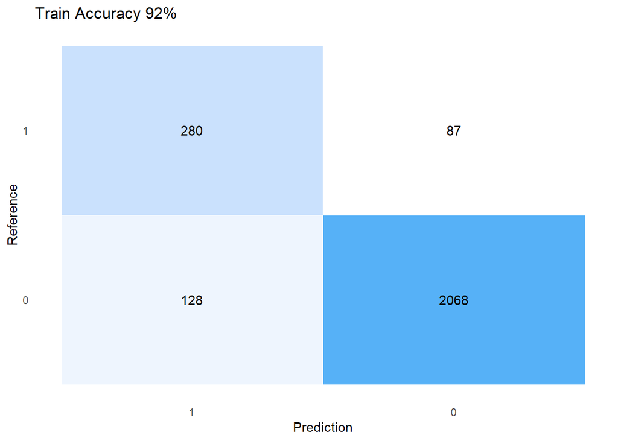

```r
ggplotConfusionMatrix <- function(m){
  mytitle <- paste("Train Accuracy", percent_format()(m$overall[1]))
  p <-
    ggplot(data = as.data.frame(m$table) ,
           aes(x = Prediction, y = Reference)) +
    geom_tile(aes(fill = log(Freq)),
              colour = "white", show.legend = FALSE) +
    scale_fill_gradient(low = "white", high = "#56B1F7") +
    geom_text(aes(x = Prediction, y = Reference,
                  label = Freq)) +
    ggtitle(mytitle) +
    scale_x_discrete(limits = rev) +
    theme_minimal() +
    theme(panel.grid.major = element_blank(),
          panel.grid.minor = element_blank())
  return(p)
}
cfm_train <- confusionMatrix(train$scam_type_grouped, y_train_pred)
ggplotConfusionMatrix(cfm_train)
```

```r
# Close the jpeg file
#dev.off()
```

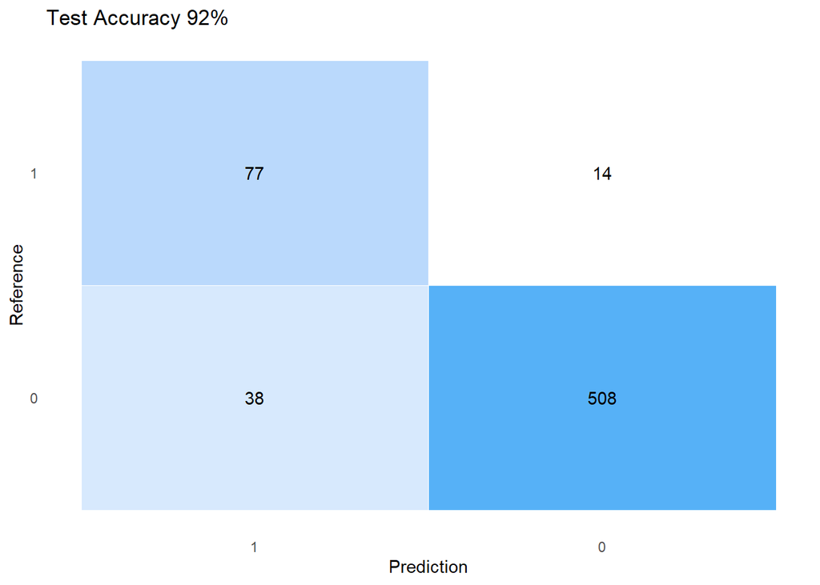

```r
# Open jpeg file
#jpeg("Test_CFM.jpg", width = 350, height = 350)

library(scales)
ggplotConfusionMatrix <- function(m){
  mytitle <- paste("Test Accuracy", percent_format()(m$overall[1]))
  p <-
    ggplot(data = as.data.frame(m$table) ,
           aes(x = Prediction, y = Reference)) +
    geom_tile(aes(fill = log(Freq)),
              colour = "white", show.legend = FALSE) +
    scale_fill_gradient(low = "white", high = "#56B1F7") +
    geom_text(aes(x = Prediction, y = Reference,
                  label = Freq)) +
    ggtitle(mytitle) +
    scale_x_discrete(limits = rev) +
    theme_minimal() +
    theme(panel.grid.major = element_blank(),
          panel.grid.minor = element_blank())
  return(p)
}
cfm_test <- confusionMatrix(test$scam_type_grouped, y_test_pred)
ggplotConfusionMatrix(cfm_test)
```

```r
# Close the jpeg file
#dev.off()
```

```r
# Train and Test Data ROC-AUC Curve
train_pred <- prediction(train_prob_pred, train$scam_type_grouped)
test_pred <- prediction(test_prob_pred, test$scam_type_grouped)

# Create an ROC curve
perf_train <- performance(train_pred, measure = "tpr", x.measure = "fpr")
perf_test <- performance(test_pred, measure = "tpr", x.measure = "fpr")
```

# 1 Plot ROC Curves and save

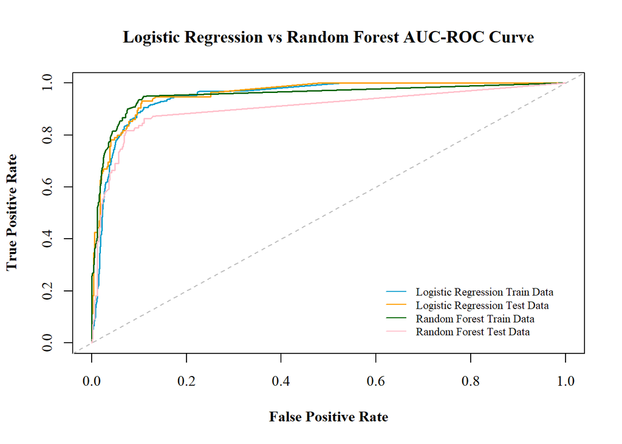

```r
# Plot the ROC curve
op <- par(family = "serif")

# Plot the ROC curve
plot(perf_train, main = "Logistic Regression vs Random Forest AUC-ROC Curve",
    col = "#009ECE", xlab = "False Positive Rate", ylab = "True Positive Rate",
    type = "l", lwd = 1.5, family="serif", cex.main = 1.15, cex.lab = 1, cex.axis = 1.05, font.axis = 2, font.lab = 2) # c
plot(perf_test, add = T, col = "#FF9E00", lwd = 1.5)
plot(rf_perf_train, add = T, col = "darkgreen", lwd = 1.5)
plot(rf_perf_test, add = T, col = "pink", lwd = 1.5)
legend(0.60, 0.25, c("Logistic Regression Train Data", "Logistic Regression Test Data", "Random Forest Train Data", "Random Forest Test Data"),
       col = c("#009ECE", "#FF9E00", "darkgreen", "pink"),
       bty = "n", lwd = 1.2, cex = 0.75)
abline(0, 1, lty = 2, col = "gray") # Add y=x line
```

```r
par(op)
```

```r
auc.train <- auc(train$scam_type_grouped, train_prob_pred)
cat("Area under the curve for Logistic Regression Train Set is: ", auc.train)
```

```
## Area under the curve for Logistic Regression Train Set is:  0.9500398
```

```r
auc.test <- auc(train$scam_type_grouped, train_prob_pred)
cat("\nArea under the curve for Logistic Regressio  Test Set is: ", auc.test)
```

[output not shown]